# Final Project

#### b. Check the residuals and produce forecasts.

TBATS doesn’t work well for the gasoline dataset. The model automatically searches for the best fit based on Box-Cox and with or without a damped trend. The bootstrapping and boosting models also didn’t perform well, but I am sure it is because of my parameters being wrong. I attempted to use a Fourier matrix change to adjust the gasoline data for the auto arima model in the bootstrapping, but the data would not fit properly.

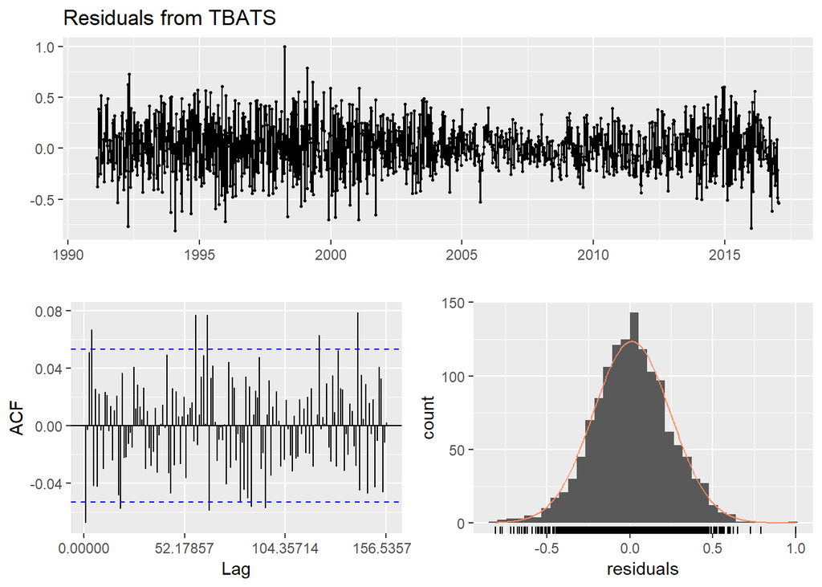

```
##
##  Ljung-Box test
##
## data:  Residuals from TBATS
## Q* = 142.77, df = 76.357, p-value = 6.302e-06
##
## Model df: 28.   Total lags used: 104.357142857143
```

```r
checkresiduals(gas_tbats)
```

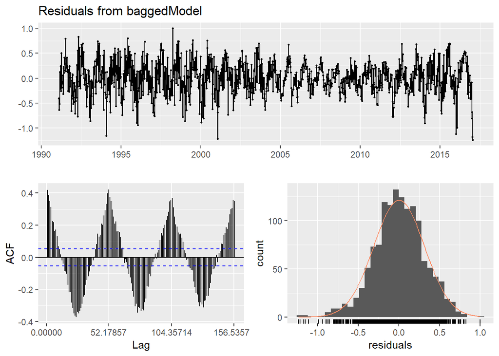

```r
checkresiduals(gas_bagged)
```

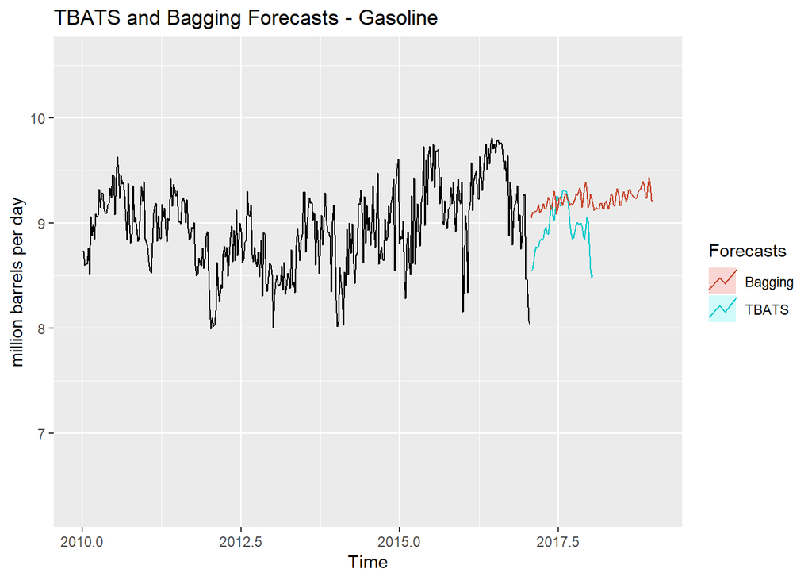

```r
# The residuals aren't like white noise.
fc_gas_tbats <- forecast(gas_tbats,h = 52)
fc_gas_bootstrap <- forecast(gas_bootstrap,h = 52)
fc_gas_bagged <- forecast(gas_bagged,h = 52,xreg = gas_fourier)
# It looks like none of these models fitted well.

autoplot(gasoline) +
  ggtitle("TBATS and Bagging Forecasts - Gasoline") +
  autolayer(fc_gas_tbats, series="TBATS", PI=FALSE) +
  autolayer(fc_gas_bagged, series="Bagging", PI=FALSE) +
  ylab("million barrels per day") +
  scale_x_continuous(limits = c(2010, 2019)) +
  guides(colour=guide_legend(title="Forecasts"))
```

```
## For a multivariate timeseries, specify a seriesname for each timeseries. Defaulting to column names.
```

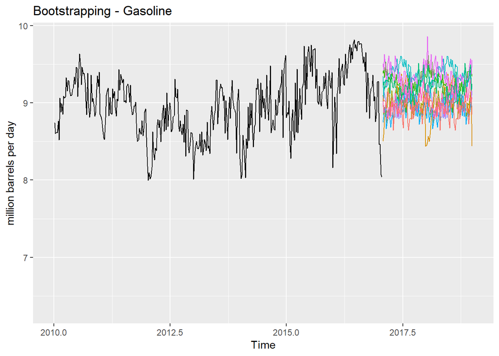

```r
autoplot(gasoline) +
  ggtitle("Bootstrapping - Gasoline") +
  autolayer(gas_bootstrap, series="Bagging", PI=FALSE) +
  scale_x_continuous(limits = c(2010, 2019)) +
  ylab("million barrels per day") +
  theme(legend.position="none")
```